# TP6: Hierarchical Model II

Author

Lionel Hertzog

Published

September 11, 2026

## 1 Objectives

This practical aims at expanding the simple hierarchical model seen in the previous practical on the same dataset of flora species richness per NFI plot.

Consider that all group-level variation can be added to all regression coefficients beyond the intercept:

$$\mu_{ij} = (\beta_0 + \gamma_j) + (\beta_1 + \delta_j) * X1_i + (\beta_2 + \nu_j) * X2_i + ...$$

With $\gamma, \delta, \nu$ sampled from normal distributions with standard deviations to be estimated.

## 2 Read the data

Load the `dat_tp5.csv` into R. Perform quick exploration of the dataset.

```r
here::i_am("practicals/tp5.qmd")
dat <- read.csv("../data/dat_tp5.csv")

head(dat)
```

```
      idp rich ser_86              pro_psg elev tcar esspre_fr
1 1005709   19    G11     privé - sans psg  319    1         R
2 1001933   50    C52     privé - sans psg  763    4         F
3 1001580   12    B33     privé - sans psg  206   10         F
4 1031119   26    I11     privé - sans psg  515   10         F
5 1007941   37    C20 publics - domaniales  465    8         F
6 1008363   35    F12 publics - domaniales  122    2         F
```

## 3 Varying-intercept only

```r
library(lme4)
m <- lmer(rich ~ elev + pro_psg + tcar + esspre_fr + (1 | ser_86),
          data = dat)
summary(m)
```

## 4 Scaling variables

To fit varying slopes, the covariables should be scaled to avoid convergence issues. Scale all continuous covariables in the dataset.

```r
dat %>%
  mutate(across(c(elev, tcar), ~ scale(.x)[,1]))  -> dat_std
```

## 5 Adding varying slope

Add varying slopes for the effect of elevation to consider potential regional variations in the effect of elevation on richness.

In `lmer` there are two options:

1. either fit uncorrelated varying effects for a same grouping factor (here the regions) using

```
lmer(y ~ ... + (1 + x1 || group))
```

2. or estimate the correlation between the varying effects for a same grouping factor using

```
lmer(y ~ ... + (1 + x1 | group))
```

```r
m_nocorr <- lmer(rich ~ elev + pro_psg + tcar + esspre_fr + (1 + elev || ser_86),
          data = dat_std)
m_corr <- lmer(rich ~ elev + pro_psg + tcar + esspre_fr + (1 + elev | ser_86),
          data = dat_std)

summary(m_corr)
summary(m_nocorr)
```

## 6 Plotting the varying slopes

### 6.1

Plot of the varying slopes per regions for the effect of elevation together with the estimated uncertainties, the deviations are available via `ranef`.

```r
ser_var <- ranef(m_corr)
ser_df <- data.frame(ser_86 = rownames(ser_var$ser_86),
                     ser_int = ser_var$ser_86[,1],
                     ser_intvar = attr(ser_var$ser_86, "postVar")[1,1,1:86],
                     ser_slp = ser_var$ser_86[,2],
                     ser_slpvar = attr(ser_var$ser_86, "postVar")[2,2,1:86])
head(ser_df)

ggplot(ser_df, aes(x = fct_reorder(ser_86, ser_slp),
                   y = ser_slp,
                   ymin = ser_slp - sqrt(ser_slpvar),
                   ymax = ser_slp + sqrt(ser_slpvar))) +
  geom_point() +
  geom_linerange() +
  coord_flip()
```

### 6.2

Plot of the varying slopes against the varying intercept.

```r
ggplot(ser_df, aes(x = ser_int, y = ser_slp)) +
  geom_point()
```

### 6.3

Plot of the effect of elevation on richness with varying regression lines for different regions.

```r
ggeffects::predict_response(m_corr, terms = c("elev", "ser_86[A11, C10, E20, F21]"), type = "random") %>%
  plot()
```

### 6.4 Bonus

Make a map of the slope variations using the sylvoécoregion shapefile, do you see some pattern emerging?

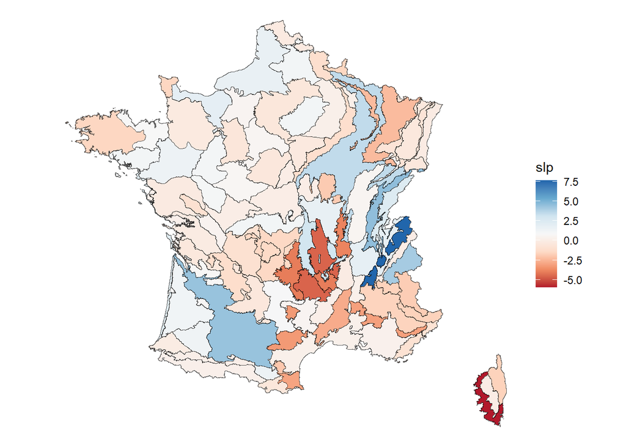

```r
library(sf)
library(tidyverse)
library(lme4)

dat$elev_std <- scale(dat$elev)[,1]
dat$tcar_std <- scale(dat$tcar)[,1]
m <- lmer(rich ~ elev_std + tcar_std + pro_psg + esspre_fr + (1 + elev_std || ser_86), dat)

ser_shape <- st_read("../data/ser_27572.gpkg")
r_slp <- ranef(m)$ser_86
ser_slp <- data.frame(ser_86 = rownames(r_slp),
                      slp = r_slp$elev_std)
ser_plot <- inner_join(ser_slp, ser_shape, by = c("ser_86" = "codeser"))

ggplot(ser_plot, aes(fill = slp, geometry = geom)) +
  geom_sf() +
  scale_fill_distiller(palette = "RdBu", direction = 1) +
  theme_void()
```

## 7 Model selection with hierarchical terms

Just like with variable selection for non-hierarchical models, the analyst need to decide which term to allow to vary between groups and if these variations are correlated or not.

Some guidelines to decide:

- Automatic inclusion of varying intercepts to account for “design” variables, such as plots
- Selection of covariable with varying slopes based on: (i) a priori research question, (ii) varying slopes added during model building to fit model assumptions (i.e. residual checks showing patterns), (iii) selection based on AIC model comparison.
- Correlation between hierarchical terms, by default off, added if needed to allow model convergence, if based on research question or to fit model assumptions.

A robust way to test for the inclusion of varying terms is via a bootstrap approach. A test statistic - like the LRT - is computed many times over bootstraped samples of the data, generating a null distribution of test statistics. If the observed test statistic is sufficiently larger than the one from the null distribution, then the additionna complexity in the model is warranted by the data.

One way to do this is with the *pbkrtest* package with the function `PBmodcomp`. Run bootstrapped test of the 4 model fitted and identify the optimal model.

```r
library(pbkrtest)

m0 <- lmer(rich ~ pro_psg + elev_std + tcar_std + esspre_fr + (1 | ser_86), dat)
m1 <- lmer(rich ~ pro_psg + elev_std + tcar_std + esspre_fr + (1 + elev_std || ser_86), dat)
m2 <- lmer(rich ~ pro_psg + elev_std + tcar_std + esspre_fr + (1 + elev_std + tcar_std || ser_86), dat)
m3 <- lmer(rich ~ pro_psg + elev_std + tcar_std + esspre_fr + (1 + elev_std + tcar_std | ser_86), dat)


models <- list(m0, m1, m2, m3)  # ordered from simplest to most complex, each nested in the next

results <- vector("list", length(models) - 1)

for (i in seq_len(length(models) - 1)) {
  results[[i]] <- PBmodcomp(models[[i + 1]], models[[i]], nsim = 100)
}

names(results) <- paste0("m", 0:(length(models)-2), "_vs_m", 1:(length(models)-1))
results
```

[output not shown]